# Lesson 6

Timothy Luna

8/22/2019

# Edge Detection: Gradients

## Intro

Previously we talked about template filtering to find a pattern. This assumed that the goal we want to find was known. The pattern was a ‘description’ of what we were looking for.

What about generic images not known in advance? What are some good features to find in a picture that might capture a lot of information to provide a good essence of the image.

## Reduced Images

These greatly reduced images are *still* meaningful. What you can see about the pictures is that the usage of pixels is quite sparse; the edges along convey much of the information.

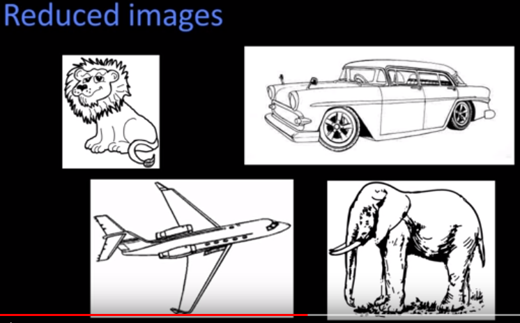

Reduced Images

## Edges

How would edges in a generic image come to be and what different kinds of edges are there? This picture has a variety of different edges.

- Depth discontinuity is a difference between fore and background.
- The shadow is an example of discontinuity in illumination.
- Surface normal discontinuity happens when an edge kinks and the normal vector to the edge changes direction.
- A color discontinuity occurs when the shape doesn’t change but the reflectance does (e.g. white to black.)

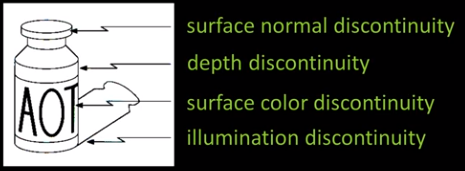

Discontinuities

The goal today is to find the edges in images. Convert an image in X,Y to a reduced set of pixels that contain the *important* bits of the image, the pieces that matter to you.

## Quiz: Change Boundaries

Edges seem to occur at “change boundaries” that are related to shape or illumination. Which of these examples is not such a boundary?

1. Occlusion (overlapping) between two people. (This alters the *shape* of the people.)
2. Cast shadow on the sidewalk. (This is a change in *illumation*.)
3. Crease in paper. (This alters the *shape* of the paper.)
4. Stripe on a sign. (This is a *color* discontinuity, or a *reflectance* change, not an illumination change.)

The stripe on a sign doesn’t come from a change in the physics or illumination, it’s from a change in the reflectance function. It’s not a function of the shape or geometry of the scene.

## Edge Detection

The question becomes ‘how do we compute to find out if a pixel in an image is an edge pixel?’ Let’s return to the idea of an image as a function and examine the image of Phyllis Dyller.

It’s very apparent that, when considering the 2D image as a 3D surface, the edges appear as very steep cliffs. So, in a local neighborhood can I detect a strong change? Two questions must be answered.

1. If looking in a neighborhood for strong change *how big is the neighborhood*?
2. If looking for a strong change *how big is strong*?

## Derivatives and Edges

Change is going to be about derivatives when we talk about functions. Here there is a very simple image with the intensity of a row plotted as a scanline. When the derivative of that scanline is plotted it’s apparent that there are local extrema in the first derivative where the edges occur. Finding edges will be based on finding peaks in the derivative.

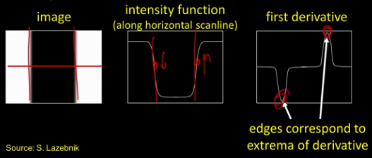

Derivative of Scanline

How can we find the peaks? Let’s use the correct operator to filter and find the peaks in the derivative.

## What is a Gradient

Differential Operators: When applied to an image it returns some derivative.

We will model these ‘operators’ as masks / kernels that compute the image gradient function. We will then *threshold* the gradient function to select the edge pixels.

So, what is a gradient?

Multivariate calculus is when you have a function or *more* than one variable. If you have a multivariate function you can take partial derivatives with respect to each variable and get the gradient.

### Gradient Definition

In a purely two dimensional image context the gradient is a function of the rate of change on the x and the rate of change on the y. This is the gradient in the X and the Y direction.

$$\nabla f=[\frac{\partial f}{\partial x},\frac{\partial f}{\partial y}]$$

In a more generalized sense the gradient is a function of the rate of change of all variables in the original function.

$$\nabla f=[\frac{\partial f}{\partial X_1},...,\frac{\partial f}{\partial X_n}]$$

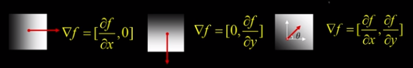

Gradients

The gradient is the direction of the most rapid increase in intensity and the magnitude is *how much* it changes in one unit step in that direction.

So, how is the gradient found?

The direction of the gradient in a purely two dimensional function can be gound by: $\Theta=tan^{-1}(\frac{\frac{\partial f}{\partial y}}{\frac{\partial f}{\partial x}})$

The magnitude of the gradient is found by: $||\nabla f||=\sqrt{(\frac{\partial f}{\partial x})^2+(\frac{\partial f}{\partial y})^2}$

The magnitude says how *rapidly* the image is changing and is *one* way to find edges! We can find large magnitudes of change.

## Quiz: Magnitude

What does it mean when the magnitude of the gradient is zero? Is the image static in the local neighborhood? Is there a local extrema? Both cases could be correct! How do you discern between them?

## Finite Differences

How do we compute the gradient without continuous math? Using the limit definition of a partial differential we can approximate the gradient.

This is called the ‘right derivative’ or the ‘right side derivative’ because we’re *adding* and moving to the right to find the gradient in the x direction.

$\frac{\partial f(x,y)}{\partial x} \approx \frac{f(x+1,y)-f(x,y)}{1}$

Is this the right way to think about this?

## Partial Derivatives of an Image

Now with RHS and LHS derivatives correlation vs convolution *matters*.

Taking the RMS of the x and y gradients gives a nice edge image!

## The Discrete Gradient

We want an operator to mask a kernel to implement a gradient.

$H=\begin{bmatrix}0 && 0 \\ -1 && 1 \\ 0 && 0\end{bmatrix}$

Is this a good operator? No! Why?

There is no middle pixel. If we wanted to go the right and the left of a pixel…

$H=\begin{bmatrix}0 && 0 && 0 \\ -\frac{1}{2} && 0 && \frac{1}{2} \\ 0 && 0 && 0\end{bmatrix}$

Is this one better? It goes to the left and the right and produces the average of the right and left derivative. The right derivative would be +1 on the right and -1 in the middle while the left derivative would be -1 on the left and +1 in the middle. Thus… the average.

## Sobel Operator

The classic derivative is named after Sobel; the Sobel operator looks like:

$$s_x = \frac{1}{8}\begin{bmatrix}-1 && 0 && 1 \\ -2 && 0 && 2 \\ -1 && 0 && 1\end{bmatrix},s_y = \frac{1}{8}\begin{bmatrix}1 && 2 && 1 \\ 0 && 0 && 0 \\ -1 && -2 && -1\end{bmatrix}$$

This looks odd! $s_y$ and $s_x$ are very similar and here positive y is up. If positive y was down, though, then $s_y = s_x^T$.

We assume the images are locally smooth; if we compute a derivative at a pixel we look not just ahead and behind but also a bit to the left and right to get local averages.

The Sobel gradient is $\nabla I=\begin{bmatrix}g_x && g_y\end{bmatrix}^T$ where $g_i$ is the application of $s_i$.

The gradient magnitude $g=(g_x^2 + g_y^2)^\frac{1}{2}$ and the direction is $\theta=atan2(g_y,g_x)$.

You can *threshold* a gradient magnitude image to cut out things that *might or might not be* edges.

## Well Known Gradients

Sobel, Prewitt, Roberts are all gradients. Although Matlab has these operators in OpenCV the easy ones to access are the Scharr and Sobel.

Here is an example of Prewitt filtering https://gist.github.com/rahit/c078cabc0a48f2570028bff397a9e154.

## Quiz: Compute Gradients

Is it better to compute gradients using convolution or correlation? Honestly, it doesn’t really matter; the results might have to be interpreted differently but both will find the edges in the appropriate locations. Correlation might be a little easier, though.

Matlab, by default, does correlation and not convolution. OpenCV does whatever you specify…